# Boston Housing data - Linear Regression

Amruta Jadhav

##### Setup

```r
# Load standard libraries
library(tidyverse)
library(MASS) # Modern applied statistics functions
require(coefplot)
```

In this problem we will use the Boston dataset that is available in the package. This dataset contains information about median house value for 506 neighborhoods in Boston, MA. Load this data and use it to answer the following questions.

```r
housing_df <- MASS::Boston  #Loading the dataset
```

Describe the data and variables that are part of the dataset. Tidy data as necessary.

```r
#Inspecting the data

colSums(is.na(housing_df))  #looking for missing values
```

```
##    crim      zn   indus    chas     nox      rm     age     dis     rad     tax
##       0       0       0       0       0       0       0       0       0       0
## ptratio   black   lstat    medv
##       0       0       0       0
```

```r
chas_factor <- as.factor(housing_df$chas)   #converting the 'chas' column to factor

df1 <- bind_cols(housing_df, chas_factor)
```

```
## * NA -> ...15
```

```r
df2 <- within(df1, rm(chas))  #removing the int chas

housing_data <- rename(df2, 'chas' = '...15')

str(housing_data)
```

```
## 'data.frame':    506 obs. of  14 variables:
##  $ crim   : num  0.00632 0.02731 0.02729 0.03237 0.06905 ...
##  $ zn     : num  18 0 0 0 0 0 12.5 12.5 12.5 12.5 ...
##  $ indus  : num  2.31 7.07 7.07 2.18 2.18 2.18 7.87 7.87 7.87 7.87 ...
##  $ nox    : num  0.538 0.469 0.469 0.458 0.458 0.458 0.524 0.524 0.524 0.524 ...
##  $ rm     : num  6.58 6.42 7.18 7 7.15 ...
##  $ age    : num  65.2 78.9 61.1 45.8 54.2 58.7 66.6 96.1 100 85.9 ...
##  $ dis    : num  4.09 4.97 4.97 6.06 6.06 ...
##  $ rad    : int  1 2 2 3 3 3 5 5 5 5 ...
##  $ tax    : num  296 242 242 222 222 222 311 311 311 311 ...
##  $ ptratio: num  15.3 17.8 17.8 18.7 18.7 18.7 15.2 15.2 15.2 15.2 ...
##  $ black  : num  397 397 393 395 397 ...
##  $ lstat  : num  4.98 9.14 4.03 2.94 5.33 ...
##  $ medv   : num  24 21.6 34.7 33.4 36.2 28.7 22.9 27.1 16.5 18.9 ...
##  $ chas   : Factor w/ 2 levels "0","1": 1 1 1 1 1 1 1 1 1 1 ...
```

### Solution:

The boston housing dataset has 506 observations and 14 variales.

Variables in order:

1. CRIM per capita crime rate by town
2. ZN proportion of residential land zoned for lots over 25,000 sq.ft.
3. INDUS proportion of non-retail business acres per town
4. CHAS Charles River dummy variable (= 1 if tract bounds river; 0 otherwise)
5. NOX nitric oxides concentration (parts per 10 million)
6. RM average number of rooms per dwelling
7. AGE proportion of owner-occupied units built prior to 1940
8. DIS weighted distances to five Boston employment centers
9. RAD index of accessibility to radial highways
10. TAX full-value property-tax rate per $10,000
11. PTRATIO pupil-teacher ratio by town
12. B 1000(Bk - 0.63)^2 where Bk is the proportion of blacks by town
13. LSTAT % lower status of the population
14. MEDV Median value of owner-occupied homes in $1000’s

Consider this data in context, what is the response variable of interest?

### Solution:

The response variable of interest is ‘MEDV’, that is the median value of owner-occupied homes in $1000’s.

For each predictor, fit a simple linear regression model to predict the response. In which of the models is there a statistically significant association between the predictor and the response? Describe your results.

### Solution:

Looking at the summary of all the lm models for all the predictors, there p-values are much less than 0.05. So, we can reject the null hypothesis and say that there is a correlation between all predictors and response variable.

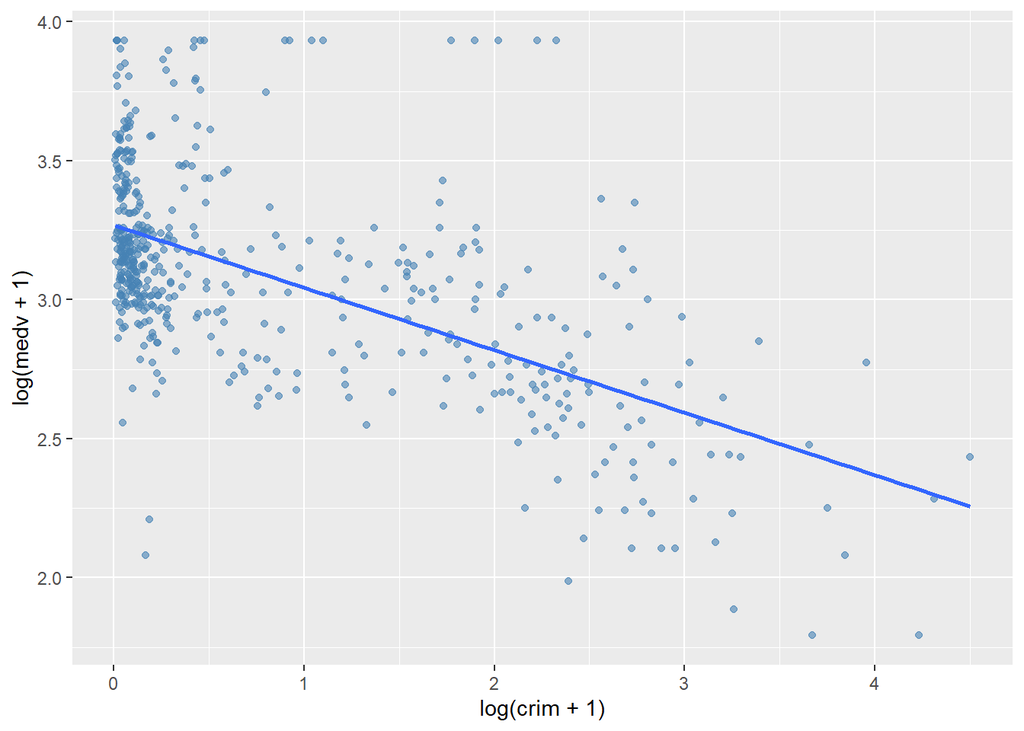

```r
# For X = crim
ggplot(housing_data, aes(log(crim+1), log(medv+1))) +
  geom_point(color = "steelblue", alpha = 0.6) + geom_smooth(method = 'lm', se = FALSE )
```

```r
crim_model <- lm(medv ~ crim, data = housing_data)
summary(crim_model)
```

```
##
## Call:
## lm(formula = medv ~ crim, data = housing_data)
##
## Residuals:
##     Min      1Q  Median      3Q     Max
## -16.957  -5.449  -2.007   2.512  29.800
##
## Coefficients:
##             Estimate Std. Error t value Pr(>|t|)
## (Intercept) 24.03311    0.40914   58.74   <2e-16 ***
## crim        -0.41519    0.04389   -9.46   <2e-16 ***
## ---
## Signif. codes:  0 '***' 0.001 '**' 0.01 '*' 0.05 '.' 0.1 ' ' 1
##
## Residual standard error: 8.484 on 504 degrees of freedom
## Multiple R-squared:  0.1508, Adjusted R-squared:  0.1491
## F-statistic: 89.49 on 1 and 504 DF,  p-value: < 2.2e-16
```

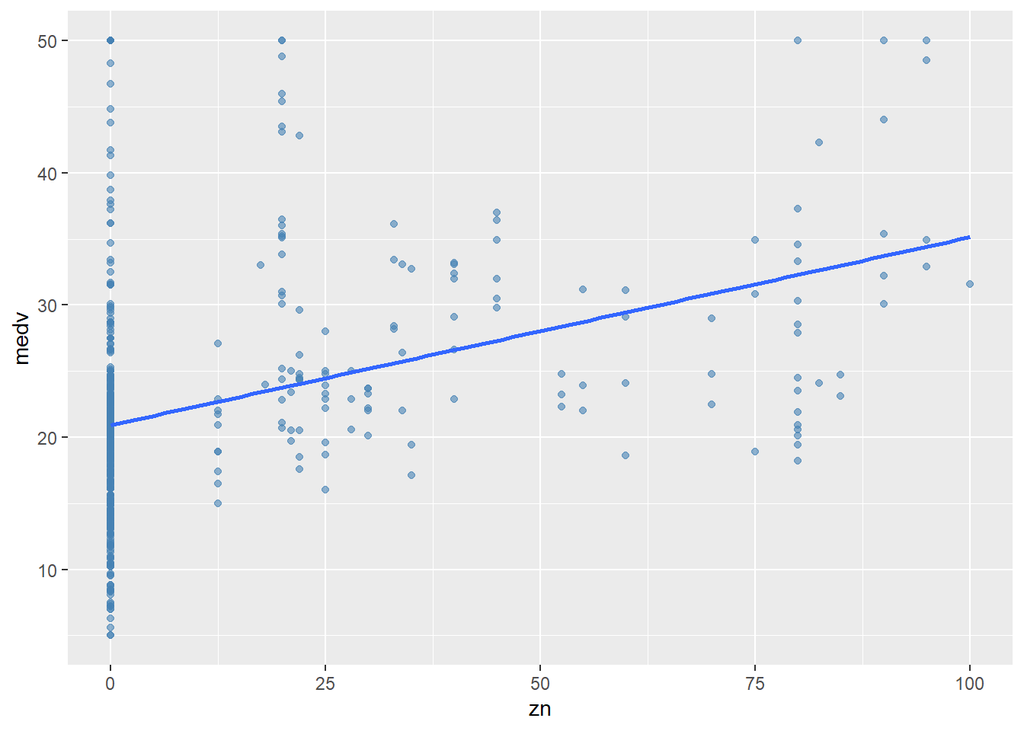

```r
# For X = zn
ggplot(housing_data, aes(zn, medv)) +
  geom_point(color = "steelblue", alpha = 0.6) + geom_smooth(method = 'lm', se = FALSE)
```

```r
zn_model <- lm(medv ~ zn, data = housing_data)
summary(zn_model)
```

```
##
## Call:
## lm(formula = medv ~ zn, data = housing_data)
##
## Residuals:
##     Min      1Q  Median      3Q     Max
## -15.918  -5.518  -1.006   2.757  29.082
##
## Coefficients:
##             Estimate Std. Error t value Pr(>|t|)
## (Intercept) 20.91758    0.42474  49.248   <2e-16 ***
## zn           0.14214    0.01638   8.675   <2e-16 ***
## ---
## Signif. codes:  0 '***' 0.001 '**' 0.01 '*' 0.05 '.' 0.1 ' ' 1
##
## Residual standard error: 8.587 on 504 degrees of freedom
## Multiple R-squared:  0.1299, Adjusted R-squared:  0.1282
## F-statistic: 75.26 on 1 and 504 DF,  p-value: < 2.2e-16
```

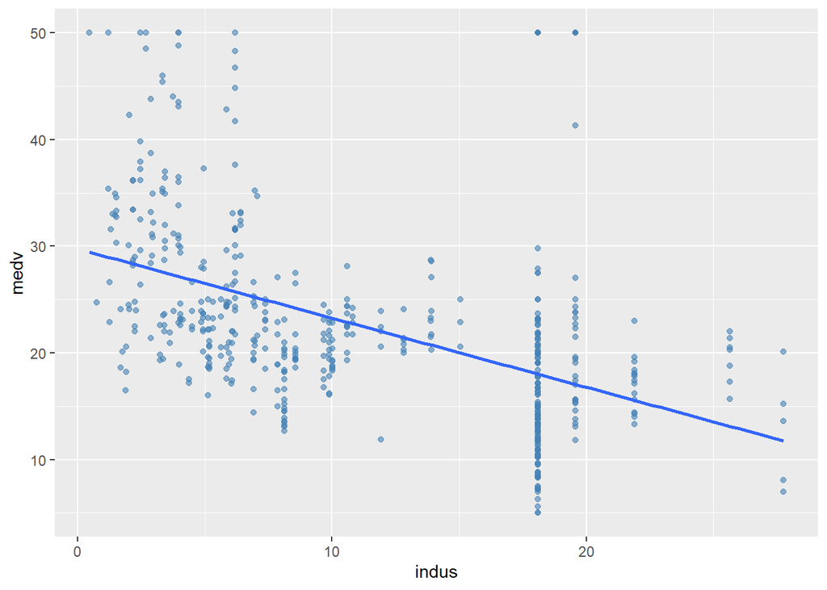

```r
#For X = indus
ggplot(housing_data, aes(indus, medv)) +
  geom_point(color = "steelblue", alpha = 0.6) + geom_smooth(method = 'lm', se = FALSE )
```

```r
indus_model <- lm(medv ~ indus, data = housing_data)
summary(indus_model)
```

```
##
## Call:
## lm(formula = medv ~ indus, data = housing_data)
##
## Residuals:
##     Min      1Q  Median      3Q     Max
## -13.017  -4.917  -1.457   3.180  32.943
##
## Coefficients:
##             Estimate Std. Error t value Pr(>|t|)
## (Intercept) 29.75490    0.68345   43.54   <2e-16 ***
## indus       -0.64849    0.05226  -12.41   <2e-16 ***
## ---
## Signif. codes:  0 '***' 0.001 '**' 0.01 '*' 0.05 '.' 0.1 ' ' 1
##
## Residual standard error: 8.057 on 504 degrees of freedom
## Multiple R-squared:  0.234,  Adjusted R-squared:  0.2325
## F-statistic:   154 on 1 and 504 DF,  p-value: < 2.2e-16
```

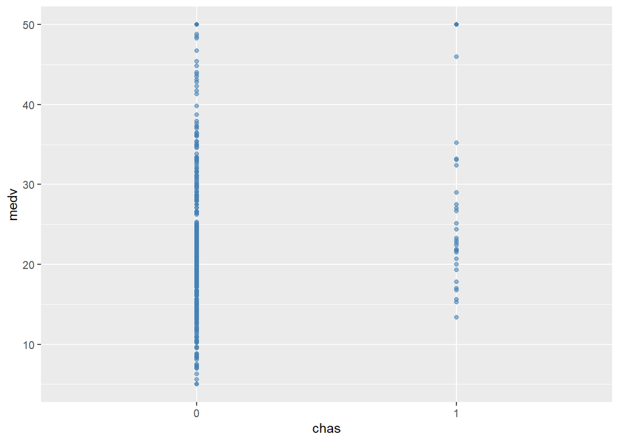

```r
#For X = chas
ggplot(housing_data, aes(chas, medv)) +
  geom_point(color = "steelblue", alpha = 0.6) + geom_smooth(method = 'lm', se = FALSE)
```

```r
chas_model <- lm(medv ~ chas, data = housing_data)
summary(chas_model)
```

```
##
## Call:
## lm(formula = medv ~ chas, data = housing_data)
##
## Residuals:
##     Min      1Q  Median      3Q     Max
## -17.094  -5.894  -1.417   2.856  27.906
##
## Coefficients:
##             Estimate Std. Error t value Pr(>|t|)
## (Intercept)  22.0938     0.4176  52.902  < 2e-16 ***
## chas1         6.3462     1.5880   3.996 7.39e-05 ***
## ---
## Signif. codes:  0 '***' 0.001 '**' 0.01 '*' 0.05 '.' 0.1 ' ' 1
##
## Residual standard error: 9.064 on 504 degrees of freedom
## Multiple R-squared:  0.03072,    Adjusted R-squared:  0.02879
## F-statistic: 15.97 on 1 and 504 DF,  p-value: 7.391e-05
```

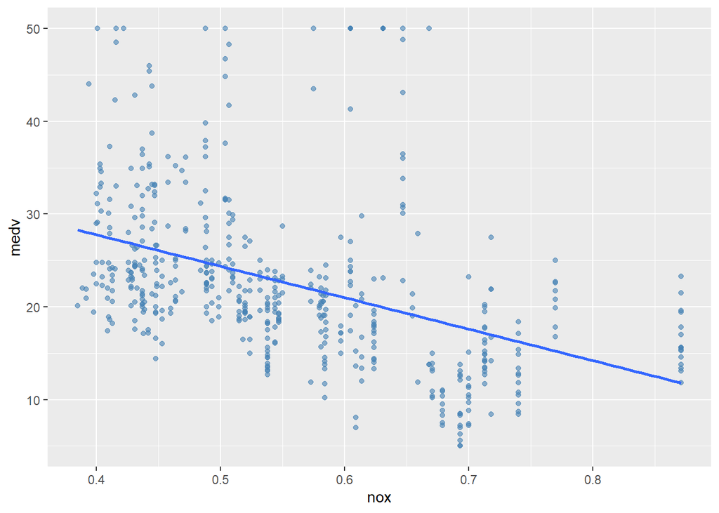

```r
#For X = nox
ggplot(housing_data, aes(nox, medv)) +
  geom_point(color = "steelblue", alpha = 0.6) + geom_smooth(method = 'lm', se = FALSE)
```

```r
nox_model <- lm(medv ~ nox, data = housing_data)
summary(nox_model)
```

```
##
## Call:
## lm(formula = medv ~ nox, data = housing_data)
##
## Residuals:
##     Min      1Q  Median      3Q     Max
## -13.691  -5.121  -2.161   2.959  31.310
##
## Coefficients:
##             Estimate Std. Error t value Pr(>|t|)
## (Intercept)   41.346      1.811   22.83   <2e-16 ***
## nox          -33.916      3.196  -10.61   <2e-16 ***
## ---
## Signif. codes:  0 '***' 0.001 '**' 0.01 '*' 0.05 '.' 0.1 ' ' 1
##
## Residual standard error: 8.323 on 504 degrees of freedom
## Multiple R-squared:  0.1826, Adjusted R-squared:  0.181
## F-statistic: 112.6 on 1 and 504 DF,  p-value: < 2.2e-16
```

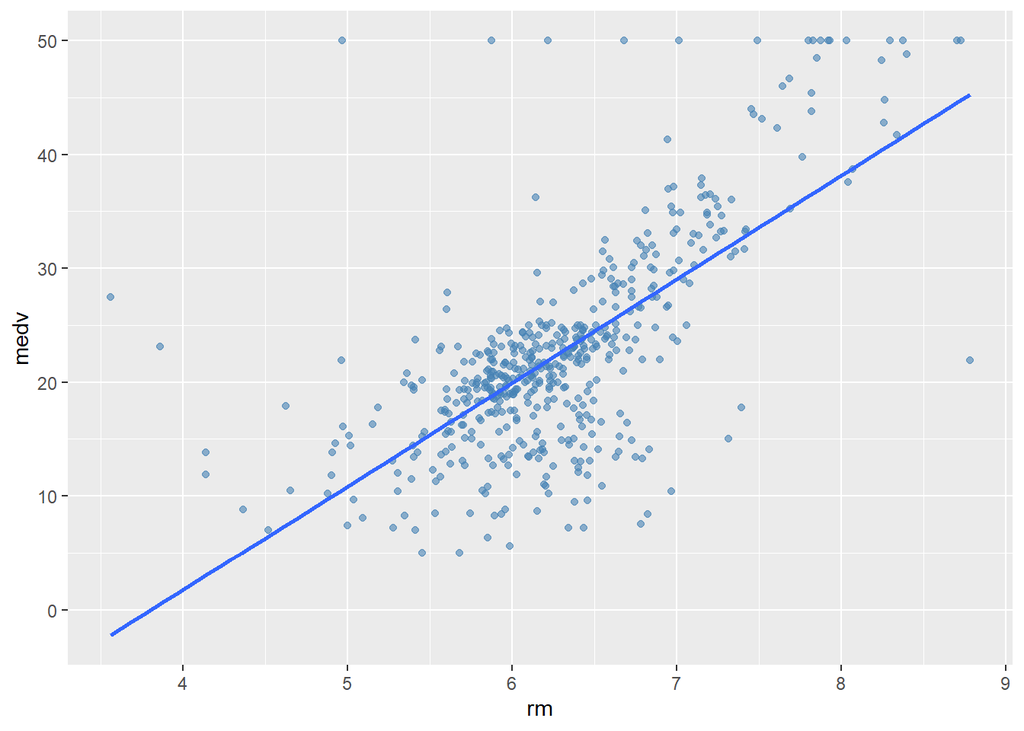

```r
#For X = rm
ggplot(housing_data, aes(rm, medv)) +
  geom_point(color = "steelblue", alpha = 0.6) + geom_smooth(method = 'lm', se = FALSE)
```

```r
rm_model <- lm(medv ~ rm, data = housing_data)
summary(rm_model)
```

```
##
## Call:
## lm(formula = medv ~ rm, data = housing_data)
##
## Residuals:
##     Min      1Q  Median      3Q     Max
## -23.346  -2.547   0.090   2.986  39.433
##
## Coefficients:
##             Estimate Std. Error t value Pr(>|t|)
## (Intercept)  -34.671      2.650  -13.08   <2e-16 ***
## rm             9.102      0.419   21.72   <2e-16 ***
## ---
## Signif. codes:  0 '***' 0.001 '**' 0.01 '*' 0.05 '.' 0.1 ' ' 1
##
## Residual standard error: 6.616 on 504 degrees of freedom
## Multiple R-squared:  0.4835, Adjusted R-squared:  0.4825
## F-statistic: 471.8 on 1 and 504 DF,  p-value: < 2.2e-16
```

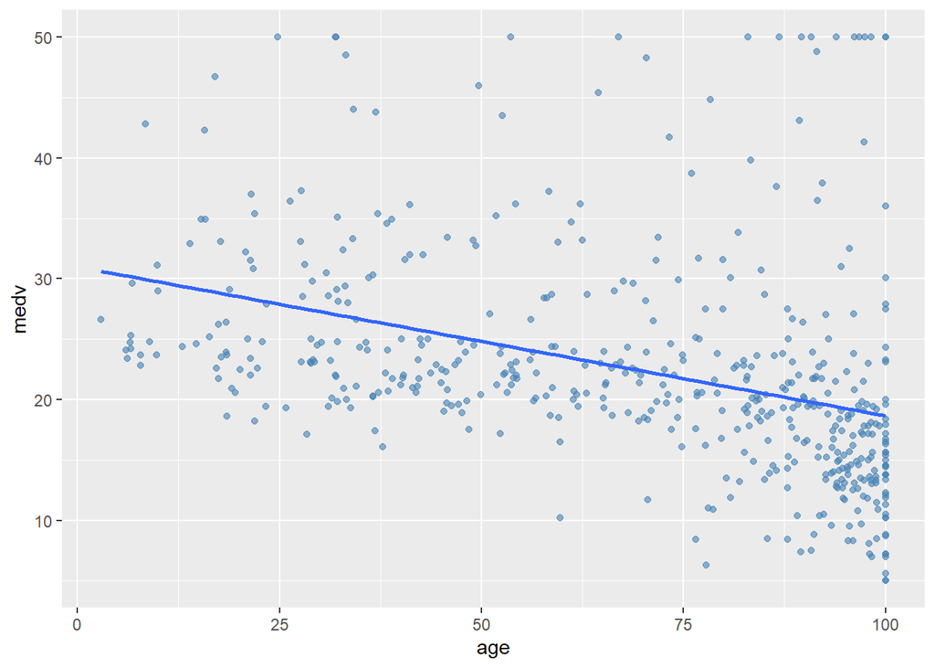

```r
#For X = age
ggplot(housing_data, aes(age, medv)) +
  geom_point(color = "steelblue", alpha = 0.6) + geom_smooth(method = 'lm', se = FALSE)
```

```r
age_model <- lm(medv ~ age, data = housing_data)
summary(age_model)
```

```
##
## Call:
## lm(formula = medv ~ age, data = housing_data)
##
## Residuals:
##     Min      1Q  Median      3Q     Max
## -15.097  -5.138  -1.958   2.397  31.338
##
## Coefficients:
##             Estimate Std. Error t value Pr(>|t|)
## (Intercept) 30.97868    0.99911  31.006   <2e-16 ***
## age         -0.12316    0.01348  -9.137   <2e-16 ***
## ---
## Signif. codes:  0 '***' 0.001 '**' 0.01 '*' 0.05 '.' 0.1 ' ' 1
##
## Residual standard error: 8.527 on 504 degrees of freedom
## Multiple R-squared:  0.1421, Adjusted R-squared:  0.1404
## F-statistic: 83.48 on 1 and 504 DF,  p-value: < 2.2e-16
```

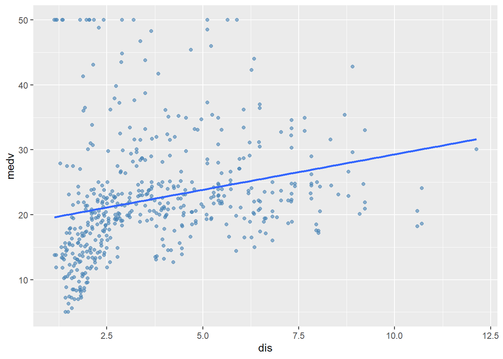

```r
#For X = dis
ggplot(housing_data, aes(dis, medv)) +
  geom_point(color = "steelblue", alpha = 0.6) + geom_smooth(method = 'lm', se = FALSE)
```

```r
dis_model <- lm(medv ~ dis, data = housing_data)
summary(dis_model)
```

```
##
## Call:
## lm(formula = medv ~ dis, data = housing_data)
##
## Residuals:
##     Min      1Q  Median      3Q     Max
## -15.016  -5.556  -1.865   2.288  30.377
##
## Coefficients:
##             Estimate Std. Error t value Pr(>|t|)
## (Intercept)  18.3901     0.8174  22.499  < 2e-16 ***
## dis           1.0916     0.1884   5.795 1.21e-08 ***
## ---
## Signif. codes:  0 '***' 0.001 '**' 0.01 '*' 0.05 '.' 0.1 ' ' 1
##
## Residual standard error: 8.914 on 504 degrees of freedom
## Multiple R-squared:  0.06246,    Adjusted R-squared:  0.0606
## F-statistic: 33.58 on 1 and 504 DF,  p-value: 1.207e-08
```

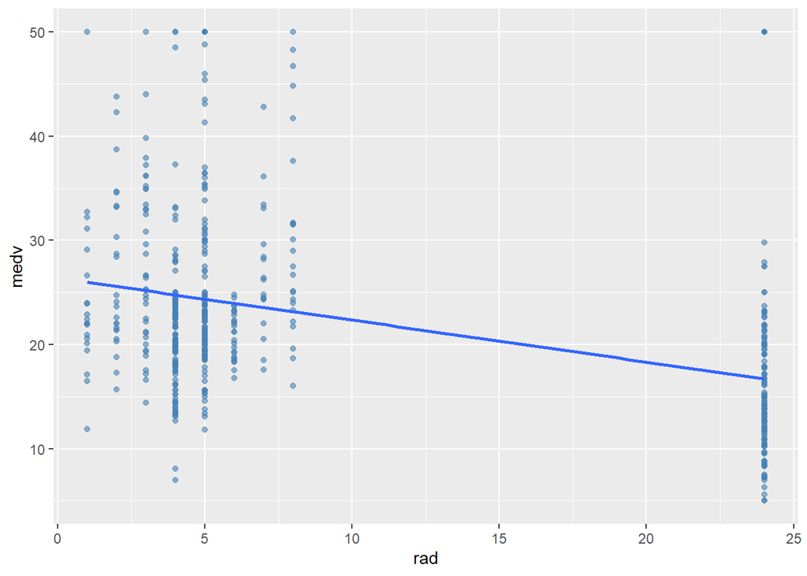

```r
#For X = rad
ggplot(housing_data, aes(rad, medv)) +
  geom_point(color = "steelblue", alpha = 0.6) + geom_smooth(method = 'lm', se = FALSE)
```

```r
rad_model <- lm(medv ~ rad, data = housing_data)
summary(rad_model)
```

```
##
## Call:
## lm(formula = medv ~ rad, data = housing_data)
##
## Residuals:
##     Min      1Q  Median      3Q     Max
## -17.770  -5.199  -1.967   3.321  33.292
##
## Coefficients:
##             Estimate Std. Error t value Pr(>|t|)
## (Intercept) 26.38213    0.56176  46.964   <2e-16 ***
## rad         -0.40310    0.04349  -9.269   <2e-16 ***
## ---
## Signif. codes:  0 '***' 0.001 '**' 0.01 '*' 0.05 '.' 0.1 ' ' 1
##
## Residual standard error: 8.509 on 504 degrees of freedom
## Multiple R-squared:  0.1456, Adjusted R-squared:  0.1439
## F-statistic: 85.91 on 1 and 504 DF,  p-value: < 2.2e-16
```

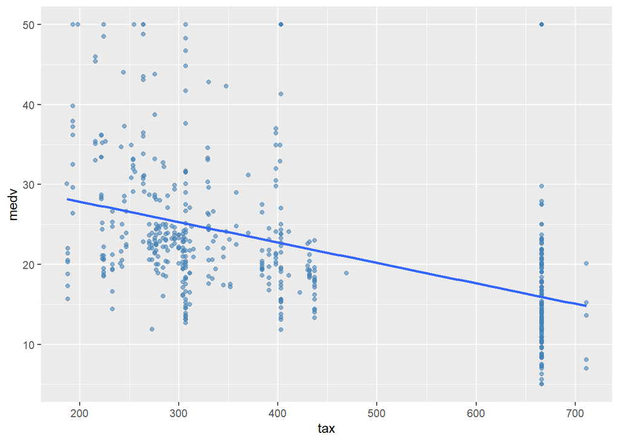

```r
#For X = tax
ggplot(housing_data, aes(tax, medv)) +
  geom_point(color = "steelblue", alpha = 0.6) + geom_smooth(method = 'lm', se = FALSE)
```

```r
tax_model <- lm(medv ~ tax, data = housing_data)
summary(tax_model)
```

```
##
## Call:
## lm(formula = medv ~ tax, data = housing_data)
##
## Residuals:
##     Min      1Q  Median      3Q     Max
## -14.091  -5.173  -2.085   3.158  34.058
##
## Coefficients:
##              Estimate Std. Error t value Pr(>|t|)
## (Intercept) 32.970654   0.948296   34.77   <2e-16 ***
## tax         -0.025568   0.002147  -11.91   <2e-16 ***
## ---
## Signif. codes:  0 '***' 0.001 '**' 0.01 '*' 0.05 '.' 0.1 ' ' 1
##
## Residual standard error: 8.133 on 504 degrees of freedom
## Multiple R-squared:  0.2195, Adjusted R-squared:  0.218
## F-statistic: 141.8 on 1 and 504 DF,  p-value: < 2.2e-16
```

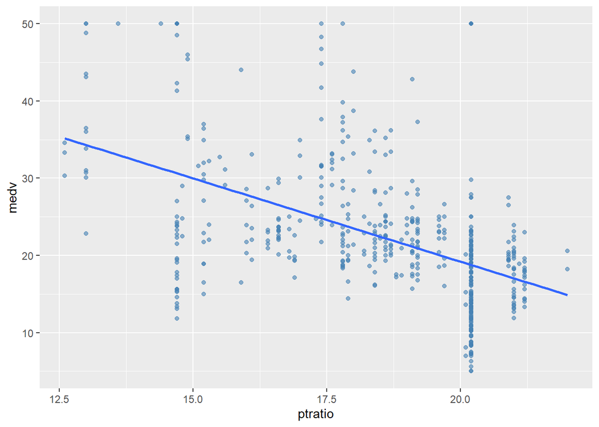

```r
#For X = ptratio
ggplot(housing_data, aes(ptratio, medv)) +
  geom_point(color = "steelblue", alpha = 0.6) + geom_smooth(method = 'lm', se = FALSE)
```

```r
pt_model <- lm(medv ~ ptratio, data = housing_data)
summary(pt_model)
```

```
##
## Call:
## lm(formula = medv ~ ptratio, data = housing_data)
##
## Residuals:
##      Min       1Q   Median       3Q      Max
## -18.8342  -4.8262  -0.6426   3.1571  31.2303
##
## Coefficients:
##             Estimate Std. Error t value Pr(>|t|)
## (Intercept)   62.345      3.029   20.58   <2e-16 ***
## ptratio       -2.157      0.163  -13.23   <2e-16 ***
## ---
## Signif. codes:  0 '***' 0.001 '**' 0.01 '*' 0.05 '.' 0.1 ' ' 1
##
## Residual standard error: 7.931 on 504 degrees of freedom
## Multiple R-squared:  0.2578, Adjusted R-squared:  0.2564
## F-statistic: 175.1 on 1 and 504 DF,  p-value: < 2.2e-16
```

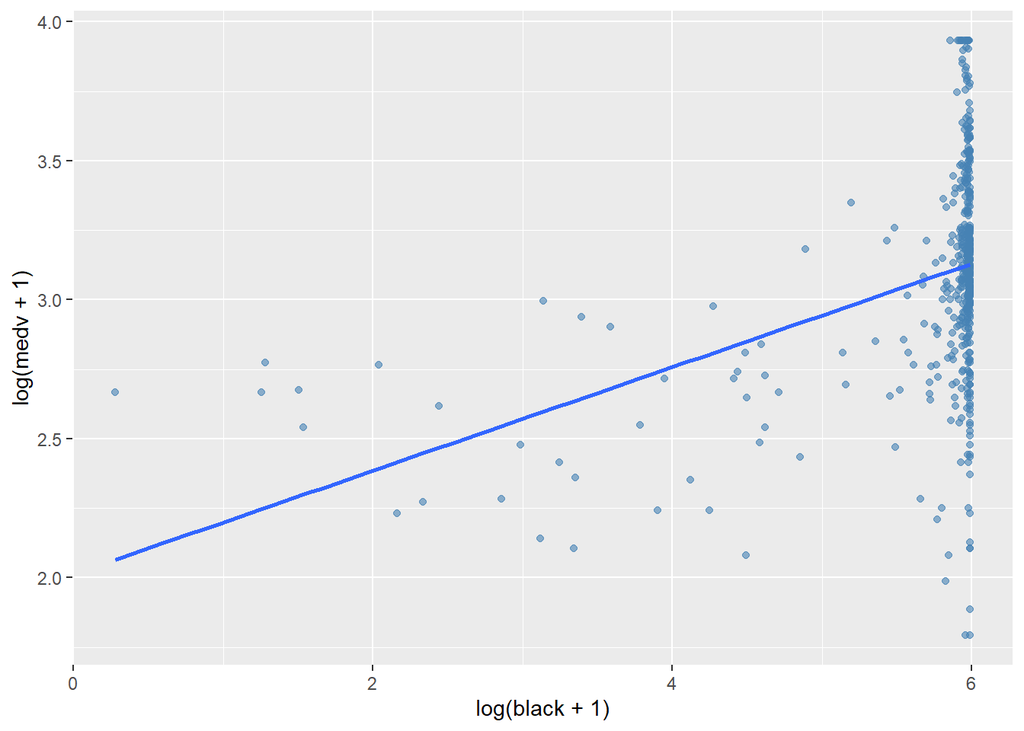

```r
#For X = black
ggplot(housing_data, aes(log(black+1), log(medv+1))) +
  geom_point(color = "steelblue", alpha = 0.6) + geom_smooth(method = 'lm', se = FALSE)
```

```r
black_model <- lm(medv ~ black, data = housing_data)
summary(black_model)
```

```
##
## Call:
## lm(formula = medv ~ black, data = housing_data)
##
## Residuals:
##     Min      1Q  Median      3Q     Max
## -18.884  -4.862  -1.684   2.932  27.763
##
## Coefficients:
##              Estimate Std. Error t value Pr(>|t|)
## (Intercept) 10.551034   1.557463   6.775 3.49e-11 ***
## black        0.033593   0.004231   7.941 1.32e-14 ***
## ---
## Signif. codes:  0 '***' 0.001 '**' 0.01 '*' 0.05 '.' 0.1 ' ' 1
##
## Residual standard error: 8.679 on 504 degrees of freedom
## Multiple R-squared:  0.1112, Adjusted R-squared:  0.1094
## F-statistic: 63.05 on 1 and 504 DF,  p-value: 1.318e-14
```

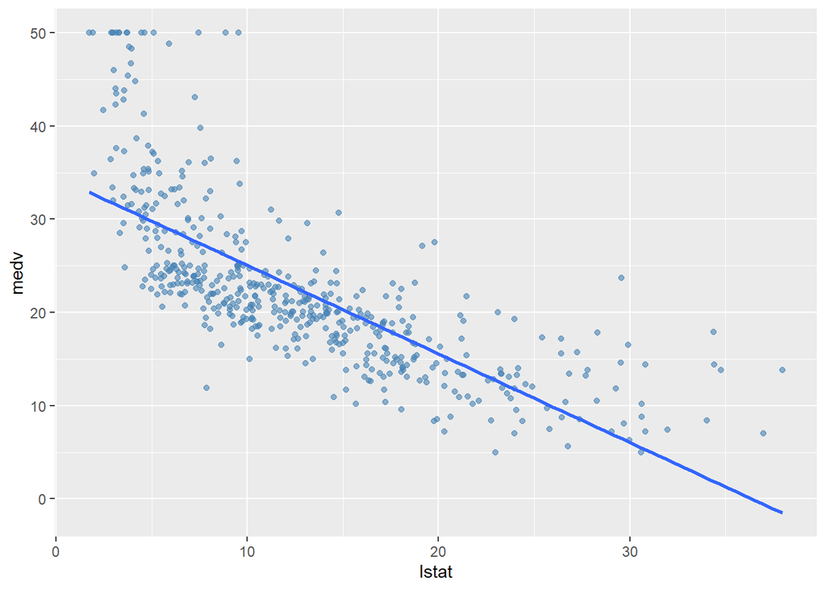

```r
#For X = lstat
ggplot(housing_data, aes(lstat, medv)) +
  geom_point(color = "steelblue", alpha = 0.6) + geom_smooth(method = 'lm', se = FALSE)
```

```r
lstat_model <- lm(medv ~ lstat, data = housing_data)
summary(lstat_model)
```

```
##
## Call:
## lm(formula = medv ~ lstat, data = housing_data)
##
## Residuals:
##     Min      1Q  Median      3Q     Max
## -15.168  -3.990  -1.318   2.034  24.500
##
## Coefficients:
##             Estimate Std. Error t value Pr(>|t|)
## (Intercept) 34.55384    0.56263   61.41   <2e-16 ***
## lstat       -0.95005    0.03873  -24.53   <2e-16 ***
## ---
## Signif. codes:  0 '***' 0.001 '**' 0.01 '*' 0.05 '.' 0.1 ' ' 1
##
## Residual standard error: 6.216 on 504 degrees of freedom
## Multiple R-squared:  0.5441, Adjusted R-squared:  0.5432
## F-statistic: 601.6 on 1 and 504 DF,  p-value: < 2.2e-16
```

Fit a multiple regression model to predict the response using all of the predictors. Describe your results. For which predictors can we reject the null hypothesis $H_0: \beta_j = 0$?

### Solution:

After looking the p-values in the model summary, we can say tha p-values of predictor ‘indus’ and ‘age’ are not less than 0.05. So we cannot reject the null hypothesis for them. We can reject the null hypothesis for all the other predictors in the data.

```r
model2 <- lm(medv ~ crim + zn + indus + chas + nox + rm + age + dis + rad + tax + ptratio + black + lstat, data = housing_data)

summary(model2)
```

```
##
## Call:
## lm(formula = medv ~ crim + zn + indus + chas + nox + rm + age +
##     dis + rad + tax + ptratio + black + lstat, data = housing_data)
##
## Residuals:
##     Min      1Q  Median      3Q     Max
## -15.595  -2.730  -0.518   1.777  26.199
##
## Coefficients:
##               Estimate Std. Error t value Pr(>|t|)
## (Intercept)  3.646e+01  5.103e+00   7.144 3.28e-12 ***
## crim        -1.080e-01  3.286e-02  -3.287 0.001087 **
## zn           4.642e-02  1.373e-02   3.382 0.000778 ***
## indus        2.056e-02  6.150e-02   0.334 0.738288
## chas1        2.687e+00  8.616e-01   3.118 0.001925 **
## nox         -1.777e+01  3.820e+00  -4.651 4.25e-06 ***
## rm           3.810e+00  4.179e-01   9.116  < 2e-16 ***
## age          6.922e-04  1.321e-02   0.052 0.958229
## dis         -1.476e+00  1.995e-01  -7.398 6.01e-13 ***
## rad          3.060e-01  6.635e-02   4.613 5.07e-06 ***
## tax         -1.233e-02  3.760e-03  -3.280 0.001112 **
## ptratio     -9.527e-01  1.308e-01  -7.283 1.31e-12 ***
## black        9.312e-03  2.686e-03   3.467 0.000573 ***
## lstat       -5.248e-01  5.072e-02 -10.347  < 2e-16 ***
## ---
## Signif. codes:  0 '***' 0.001 '**' 0.01 '*' 0.05 '.' 0.1 ' ' 1
##
## Residual standard error: 4.745 on 492 degrees of freedom
## Multiple R-squared:  0.7406, Adjusted R-squared:  0.7338
## F-statistic: 108.1 on 13 and 492 DF,  p-value: < 2.2e-16
```

How do your results from (3) compare to your results from (4)? Create a plot displaying the univariate regression coefficients from (3) on the x-axis and the multiple regression coefficients from part (4) on the y-axis. Use this visualization to support your response.

### Solution:

```r
# Taking the co-efficient of the predictors from question(3)

model1 <- crim_model$coefficients[2]
model1 <- append(model1, zn_model$coefficients[2])
model1 <- append(model1, indus_model$coefficients[2])
model1 <- append(model1, chas_model$coefficients[2])
model1 <- append(model1, nox_model$coefficients[2])
model1 <- append(model1, rm_model$coefficients[2])
model1 <- append(model1, age_model$coefficients[2])
model1 <- append(model1, dis_model$coefficients[2])
model1 <- append(model1, rad_model$coefficients[2])
model1 <- append(model1, tax_model$coefficients[2])
model1 <- append(model1, pt_model$coefficients[2])
model1 <- append(model1, black_model$coefficients[2])
model1 <- append(model1, lstat_model$coefficients[2])

model1
```

```
##         crim           zn        indus        chas1          nox           rm
##  -0.41519028   0.14213999  -0.64849005   6.34615711 -33.91605501   9.10210898
##          age          dis          rad          tax      ptratio        black
##  -0.12316272   1.09161302  -0.40309540  -0.02556810  -2.15717530   0.03359306
##        lstat
##  -0.95004935
```

```r
#Extracting the co-efficient of the multiple model from question(4)
multiple_model <- model2$coefficients[2:14]

multiple_model
```

```
##          crim            zn         indus         chas1           nox
## -1.080114e-01  4.642046e-02  2.055863e-02  2.686734e+00 -1.776661e+01
##            rm           age           dis           rad           tax
##  3.809865e+00  6.922246e-04 -1.475567e+00  3.060495e-01 -1.233459e-02
##       ptratio         black         lstat
## -9.527472e-01  9.311683e-03 -5.247584e-01
```

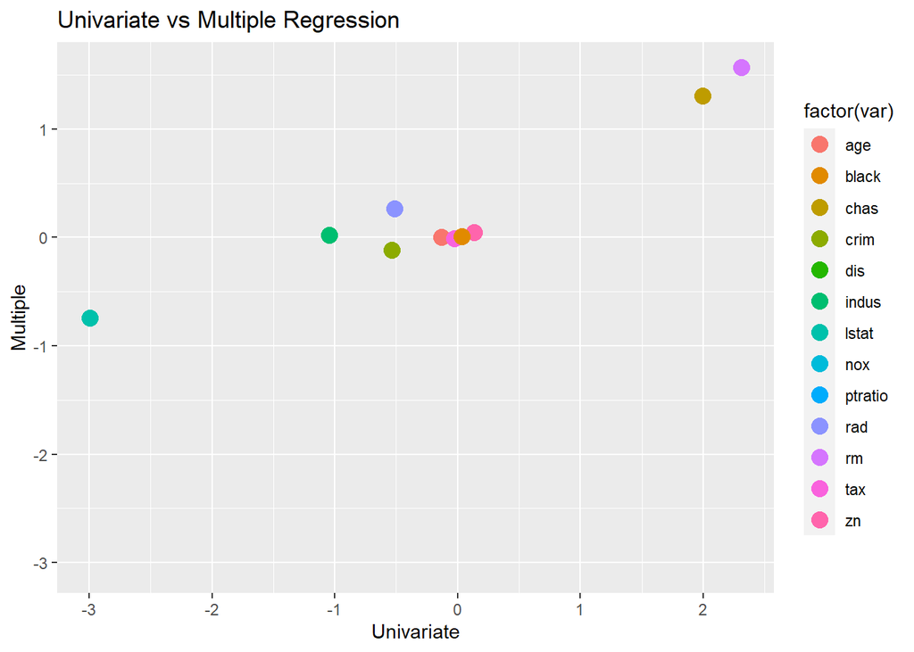

```r
#Creating a data frame for plotting
coef_df <- data.frame(model1, multiple_model, var = c("crim", "zn", "indus","chas", "nox", "rm", "age", "dis", "rad", "tax", "ptratio", "black", "lstat"))

#Plotting the co-efficient
ggplot(coef_df, aes(log(model1+1), log(multiple_model+1))) +
  geom_point(size = 4, aes(color = factor(var))) + labs(x = "Univariate", y = "Multiple", title = "Univariate vs Multiple Regression ")
```